# ERSST-short

Dario Lepke

25 6 2021

## Download and file merging

Data comes in seperate files for each month but can be downloaded to the working directory via bash.

```bash
yr=1880
while [ $yr -le 2016 ]; do
nm=1
while [ $nm -le 12 ]; do
if [ $nm -lt 10 ]; then
nm=0$nm
fi
wget ftp://ftp.ncdc.noaa.gov/pub/data/cmb/ersst/v5/netcdf/ersst.v5.$yr$nm.nc
nm=`expr $nm + 1`
done
yr=`expr $yr + 1`
done
```

We then use the Climate Data Operators (CDO) Software to handle the files for preprocessing. We do so by using the CDO software on an Ubuntu distribution installed on Windows via WSL2. To access the files on Windows in the C folder via Ubuntu we use.

```bash
cd /mnt/c
```

Then the working directory has to be set to the location of the repository “MA-climate”. After that we can use the following command to merge the single files into one.

```bash
cdo mergetime data/raw/sst/ersst/*.nc data/raw/sst/ersst.nc
```

Note you may have to check and change the maximum number of open files.

```bash
ulimit -n 2000
```

## Quick overview

We load and inspect the data.

### Variables

```r
ersst <- nc_open("../../data/raw/sst/ersst.nc")
names(ersst$var)
```

```
## [1] "sst"  "ssta"
```

We see the file contains **two variables** that are measured across different dimensions. The two variables contain the **sea surface temperatures and the respective SST anomalies** (with respect to the 1971-2000 monthly climatology). Both are measured in celsius and we are **primarly interested in the anomalies** here.

### Dimensions

```r
ersst_data <- ncvar_get(ersst, "ssta")
dim(ersst_data)
```

```
## [1]  180   89 1644
```

The data is given on longitude and latitude grid, denoting the first two dimensions. The third dimension gives the number of months that were observed. Note also that there is a fourth dimension in the dataset which gives the depth in which the measurements were taken (“lev”), but this is all 0.

```r
names(ersst$dim)
```

```
## [1] "time" "lon"  "lat"  "lev"
```

```r
ersst$dim$lev$vals
```

```
## [1] 0
```

#### Latitude and Longitude

```r
# get lon and lat
ersst_lon <- ncvar_get(ersst, "lon")
range(ersst_lon)
```

```
## [1]   0 358
```

```r
ersst_lat<- ncvar_get(ersst, "lat")
range(ersst_lat)
```

```
## [1] -88  88
```

The longitude ranges from 0 to 358 and the latitude from -88 to 88 degrees.

#### Time

```r
ersst_time <- ncvar_get(ersst,"time")
ersst_time_units <- ncatt_get(ersst, "time", attname = "units")
ersst_time_units$value
```

```
## [1] "minutes since 1880-01-01 00:00"
```

Time is measured in minutes since 1880-01-01

### Summary merged file

The data contains **1644 months** of Sea Surface Temperature data, in the geographical window from **0 to 358** longitude and **-88 to 88** latitude respectively. On a **resolution of 2.0 degree grid**. The temperature is measured in celsius. The reference for the timestamps is **minutes since 1880-01-01.**

## Preprocessing data structure

We now preprocess the data so we can use it together with the CHIRPS data. Via **selyear** we select the time frame that is covered by both datasets, namely 1981 until 2016. With **sellonlatbox** we change the orientation of the grid cells so that they are the same in both datasets. By using **setreftime** we set the origin date for the timestamps and the respective time unit, also to be the same in both data sets.

```bash
cdo -z zip selyear,1981/2016 data/raw/sst/ersst.nc data/interim/sst/ersst_selyear.nc

cdo -z zip sellonlatbox,-180,180,-90,90 data/interim/sst/ersst_selyear.nc data/interim/sst/ersst_sellonlatbox.nc

cdo -z zip setreftime,1900-1-1,00:00:00,months data/interim/sst/ersst_sellonlatbox.nc data/interim/sst/ersst_setreftime.nc
```

## First Plot

And plot one month of data.

```r
ersst <- nc_open("../../data/interim/sst/ersst_setreftime.nc")
ersst_data <- ncvar_get(ersst, "ssta")
ersst_lon <- ncvar_get(ersst, "lon")
ersst_lat <- ncvar_get(ersst, "lat")
fill_val <- ncatt_get(ersst, "ssta", "_FillValue")
ersst_data[ersst_data == fill_val$value] <- NA
```

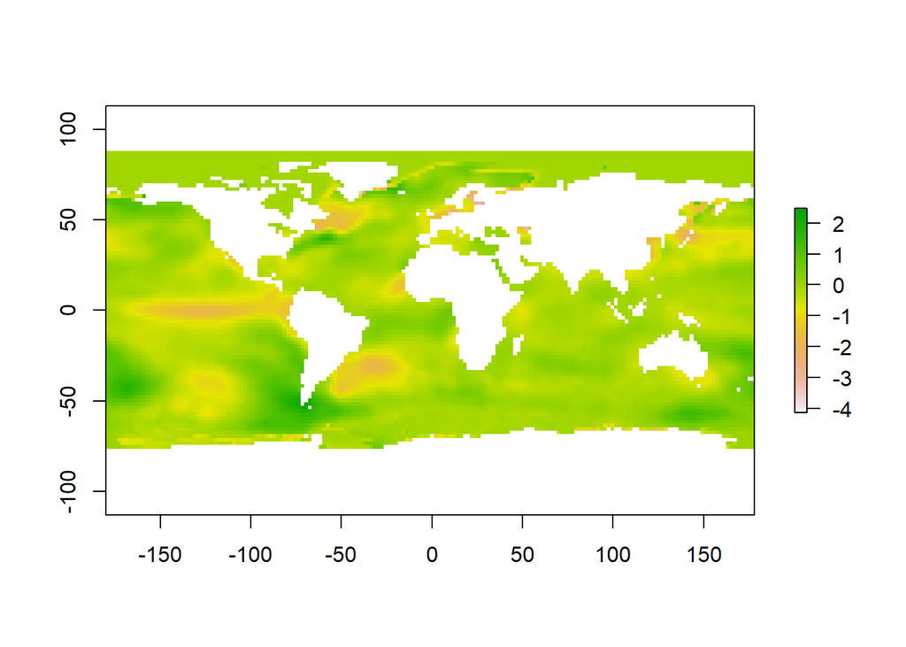

```r
set.seed(42)
m <- sample(seq(dim(ersst_data)[3]), 1)
slice <- ersst_data[,,m]
r <- raster(t(slice), xmn = min(ersst_lon), xmx = max(ersst_lon), ymn = min(ersst_lat), ymx = max(ersst_lat),
            crs = CRS("+proj=longlat +ellps=WGS84 +datum=WGS84 +no_defs+ towgs84=0,0,0"))
r <- flip(r, direction = "y")
plot(r)
```

## Appendix

Contains all the meta information on the merged file. Also a change log

```r
print(ersst)
```

```
## File ../../data/interim/sst/ersst_setreftime.nc (NC_FORMAT_CLASSIC):
##
##      2 variables (excluding dimension variables):
##         float sst[lon,lat,lev,time]
##             standard_name: sea_surface_temperature
##             long_name: Extended reconstructed sea surface temperature
##             units: degree_C
##             _FillValue: -999
##             missing_value: -999
##         float ssta[lon,lat,lev,time]
##             long_name: Extended reconstructed SST anomalies
##             units: degree_C
##             _FillValue: -999
##             missing_value: -999
##
##      4 dimensions:
##         time  Size:432   *** is unlimited ***
##             standard_name: time
##             long_name: Start time of month
##             units: months since 1900-1-1 00:00:00
##             calendar: 360_day
##             axis: T
##         lon  Size:180
##             standard_name: longitude
##             long_name: Longitude
##             units: degrees_east
##             axis: X
##         lat  Size:89
##             standard_name: latitude
##             long_name: Latitude
##             units: degrees_north
##             axis: Y
##         lev  Size:1
##             standard_name: depth
##             long_name: Depth of sea surface temperature measurements
##             units: meters
##             positive: down
##             axis: Z
##             _CoordinateAxisType: Height
##             comment: Actual measurement depth of in situ sea surface temperature varies from 0.2 to 10 m, but corrected to the nominal depth of buoy at 0.2 m
```

[output cut: 32 more lines]

```
##         geospatial_lon_units: degrees_east
##         geospatial_lon_resolution: 2
##         spatial_resolution: 2.0 degree grid
##         cdm_data_type: Grid
##         processing_level: NOAA Level 4
##         standard_name_vocabulary: CF Standard Name Table (v40, 25 January 2017)
##         keywords: Earth Science > Oceans > Ocean Temperature > Sea Surface Temperature
##         keywords_vocabulary: NASA Global Change Master Directory (GCMD) Science Keywords
##         project: NOAA Extended Reconstructed Sea Surface Temperature (ERSST)
##         platform: Ship and Buoy SSTs from ICOADS R3.0 and NCEP GTS
##         instrument: Conventional thermometers
##         comment: SSTs were observed by conventional thermometers in Buckets (in sulated or un-insulated canvas and wooded buckets), Engine Room Intakers, or floats and drifters
##         references: Huang et al, 2017: Extended Reconstructed Sea Surface Temperatures Version 5 (ERSSTv5): Upgrades, Validations, and Intercomparisons. Journal of Climate, https://doi.org/10.1175/JCLI-D-16-0836.1
##         climatology: Climatology is based on 1971-2000 SST, Xue, Y., T. M. Smith, and R. W. Reynolds, 2003: Interdecadal changes of 30-yr SST normals during 1871.2000. Journal of Climate, 16, 1601-1612.
##         CDO: Climate Data Operators version 1.9.9rc1 (https://mpimet.mpg.de/cdo)
```

```r
nc_close(ersst)
```